# Stone Data Challenge - Visualização de Dados

Por Max Mitteldorf

## Análise Exploratória

A partir de agora buscarei conduzir uma análise explorátória da base de dados unificada, com dados da Stone e do ipeadata. Nesta etapa focarei meus comentários na análise dos resultados e nos trechos de código mais importantes. Omitirei os códigos para os gráficos porque eles ocupariam um espaço muito grande.

### `TPV Mensal`

Começarei pelo TPV Mensal, nossa variável explicativa, e portanto, a mais importante. Vamos observar sua distribuição:

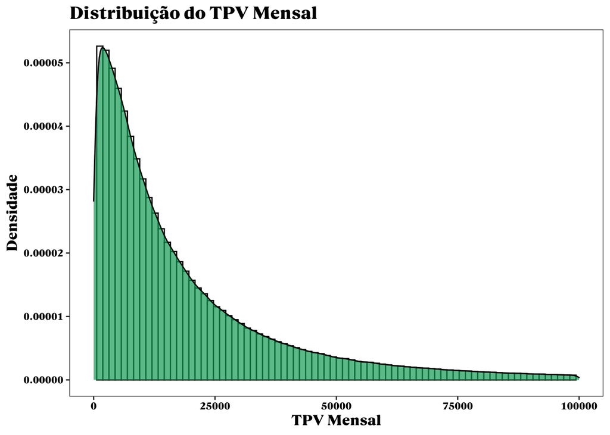

É possível observar que a distribuição dos TPVs mensais possui um grande assimetria positiva, indicando que a maior parte das empresas e clientes stone concentram-se em faixas menores de faturamento.  
Vamos investigar mais um pouco a distribuição do TPV. Vamos ver como ela se distribui pelos estados. Vamos primeiro agrupar a base por estado e calcular a média do TPV de cada um:

```r
### Number of clients by state
df %>% group_by(Estado) %>%
  summarise(TPV_mensal = mean(TPV_mensal)) %>%
  head(n=10)
```

```
## # A tibble: 10 x 2
##    Estado TPV_mensal
##    <chr>       <dbl>
##  1 AC         13778.
##  2 AL         21871.
##  3 AM         16293.
##  4 AP         21823.
##  5 BA         19383.
##  6 CE         22902.
##  7 DF         27776.
##  8 ES         16858.
##  9 GO         19706.
## 10 MA         17032.
```

Agora já podemos desenhar o gráfico de barras:

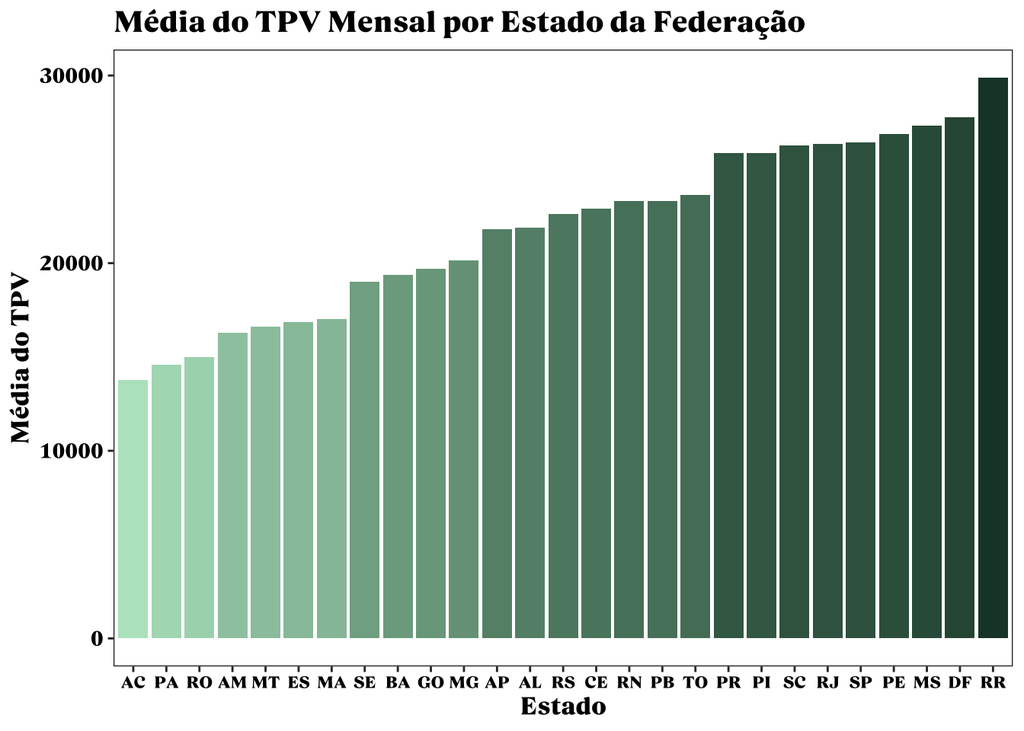

Podemos ver que roraima é o estado com a maior média de TPV mensal. Isso pode parecer surpreendente a princípio, mas devemos nos atentar também à quantidade de clientes nesse estado para verificar se isso não é efeito de algum outlier. Do outro lado o estado com menor faturamento médio é o Acre. Apesar desses valores não esperados vemos uma tendência geral dos estados mais ricos terem uma média de faturamento maior.  
Agora para vamos investigar o número de clientes por estado para confirmar a suspeita sobre Roraima:

```r
### Number of clients by state
states = df %>%
  as_tibble() %>%
  count(Estado) %>%
  drop_na() %>%
  rename("n_clientes"=n) %>%
  arrange(n_clientes)

head(states, n=5)
```

```
## # A tibble: 5 x 2
##   Estado n_clientes
##   <chr>       <int>
## 1 AC           7437
## 2 AP           7654
## 3 RR          11167
## 4 PI          11348
## 5 TO          12087
```

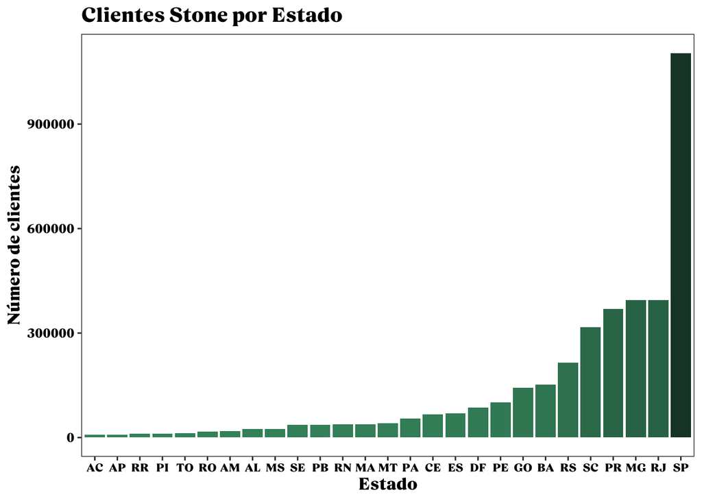

Podemos ver que nossa suspeita sobre Roraima se confirmou. Muito provavelmente existe algum outlier com faturamento muito alto em Roraima. Além disso vemos que Pão Paulo tem mais que o dobro de clientes que o segundo colocado (Rio de Janeiro). Vemos que a Stone tem uma presença maior na região Sudeste, seguida pela região Sul.  
Agora vamos investigar como varia a média do TPV para cada Macro Classificação se setores:  
Antes de fazer o gráfico precisamos agrupar o dataframe por Macro Classificação:

```r
## Agrupando
df_est = df %>% group_by(MacroClassificacao) %>%
  summarise(TPV_mensal = mean(TPV_mensal)) %>%
  drop_na() %>%
  arrange(TPV_mensal)

## Ordem
limits_mac = df_est$MacroClassificacao
```

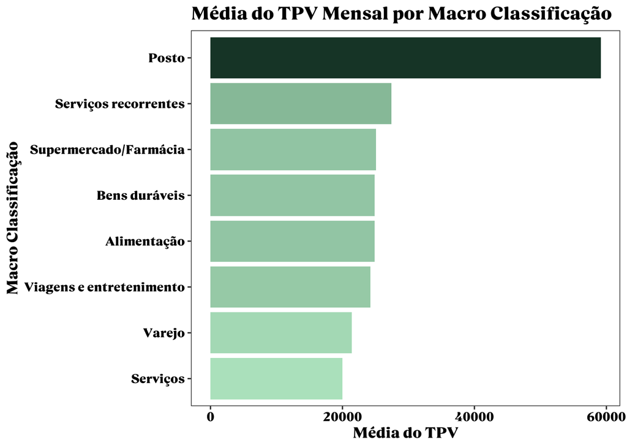

Podemos ver que dentre as áreas de Macro Classificação, os postos de gasolina apresentam um faturameto muito superior em relação aos demais grupos.  
Vamos investigar um pouco mais a fundo a média do TPV entre diversos setores. Dessa vez vamos agrupar a base pela variável segmento:

```r
## Agrupando
df_seg = df %>% group_by(segmento) %>%
  summarise(TPV_mensal = mean(TPV_mensal)) %>%
  drop_na() %>%
  arrange(TPV_mensal)

## Ordem
limits_seg = df_seg$segmento
```

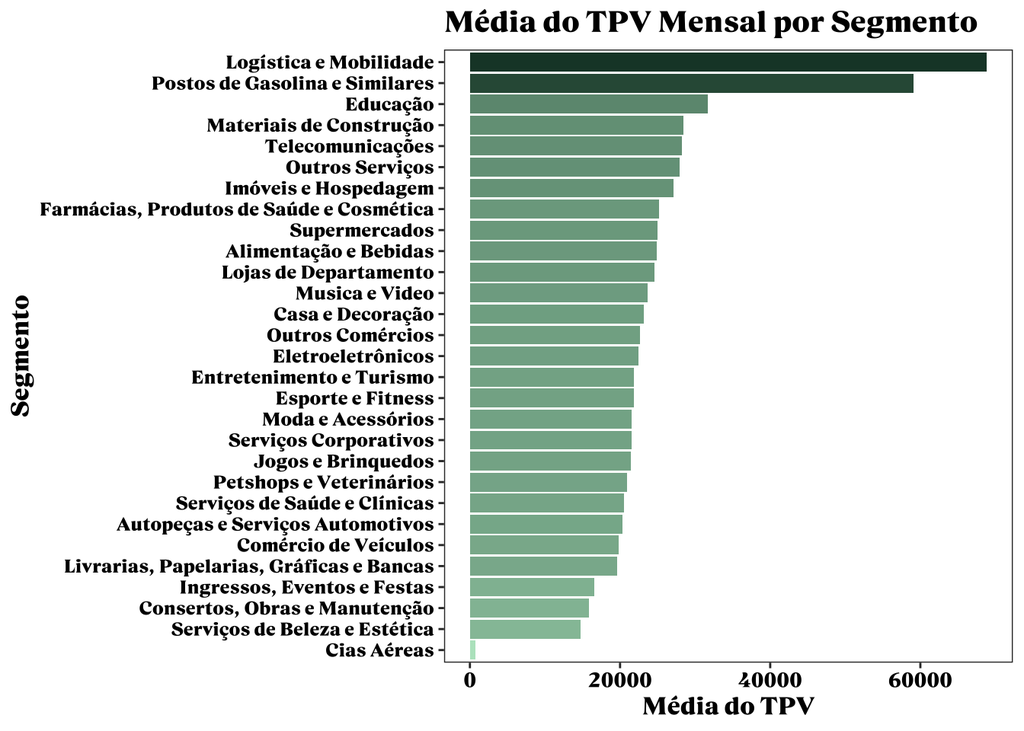

Podemos ver que os segmentos de logístiva e de postos de gasolia são os com maior média de faturamento. Serviços de beleza e companhias aparecem por último. Apesar disso o valor de companhias aéreas parece ser anormalmente baixo.

### `Variáveis do ipeadata`

Agora vamos analisar um pouco as variáveis do ipeadata. A melhro forma de começar é construindo um heatmap das correlações entre elas e o TPV mensal:

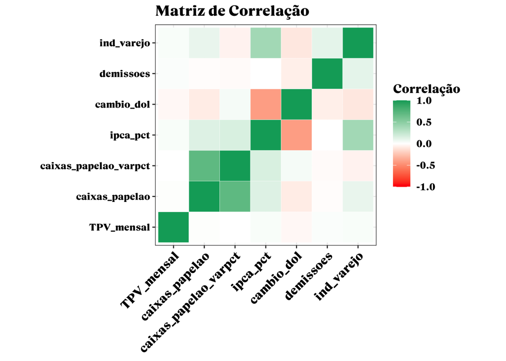

Observando-se a matriz vemos que as correlações entre as variáveis do ipeadata e o TPV mensal não são muito altas. Apesar disso vemos uma correlação ligeiramente positiva com o ipca e o índice de varejo, e uma correlação lugeiramente negativa com o dólar. Esses efeitos estão dentro do esperado uma vez que o nível de câmbio e a inflação tem um efeito direto no faturamento. Devemos nos manter atentos porque há diversos segmentos de clientes que podem ter diferentes interações com essas variáveis, que acabam mascaradas quando agregadas.  
Ainda quero ressaltar que será adicionado lag temporal e médias móveis a todas essas variáveis posteriormente. Uma vez que esperamos uma forte característica autoregressiva no modelo.  
Como acabei de comentar vamos ver o impacto dessas variáveis no TPV de forma mais detalhada. Primeiramente vamos começar vendo o impacto do nível do ipca de acordo com as Macro Classificações de clientes:

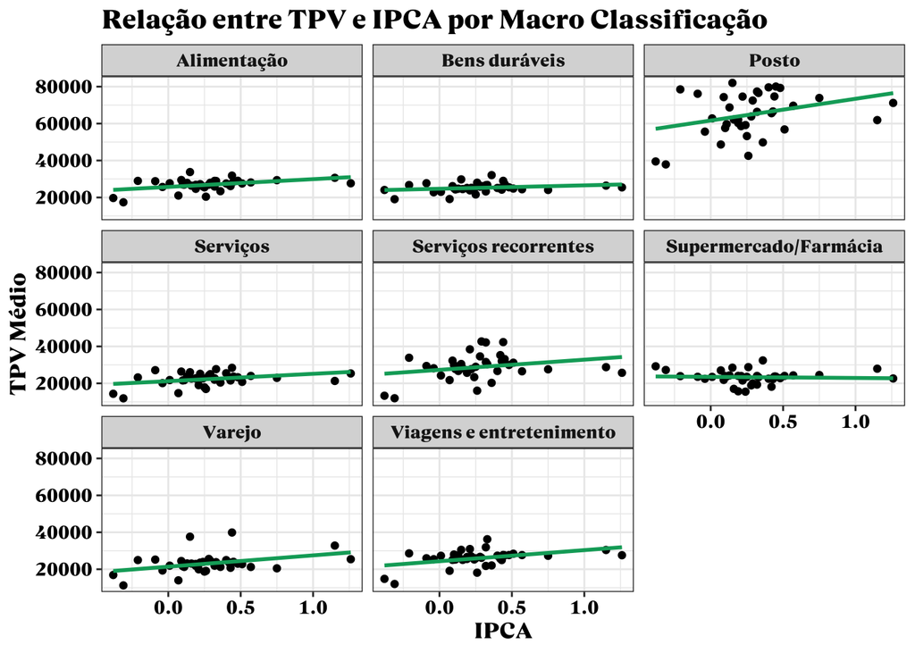

Observando os gráficos podemos ver uma ligeira tendência positiva (embora pequena) entre inflação(IPCA) e o TPV. Além disso vemos que o faturamento de postos de gasolina é o mais sensível à inflação. Provavelmente por ser um setor monopolizado o ajustes dos preços ocorre mais rapidamente.  
Vamos agora construir o mesmo gráfico para a taxa de câmbio e ver se nossas expectativas estavam corretas:

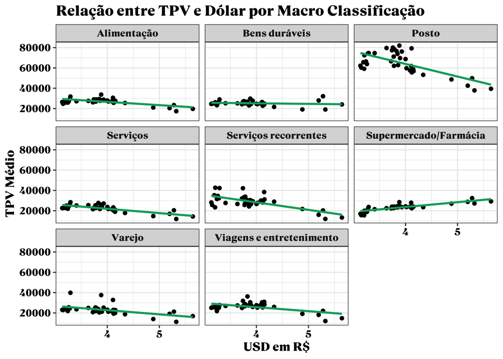

Estávamos corretos! É possível ver uma clara relação negativa entre o preço do dólar em reais e o TPV. O setor de postos tem seu faturamento muito prejudicado com um dólar mais apreciado. Por outro lado vemos que o setor de supermercados e farmácias tem um aumento em seu faturamento (provavelmente por serem setores essenciais). Varejo e entretenimento também são prejudicados pelo aumento do dólar.  
O que aprendemos com isso? Que analisar a correlação com todos os setores agrupados esconde o poder preditivo de muitas variáveis. Dessa forma nnosso “feeling econômico” de que tias variáveis eram importantes estava correto.  
Vamos observar agora a relação entre o TPV e o índice de nível do varejo. É de se esperar que tal relação seja mais forte para o macro setor de varejo. Vamos ver:

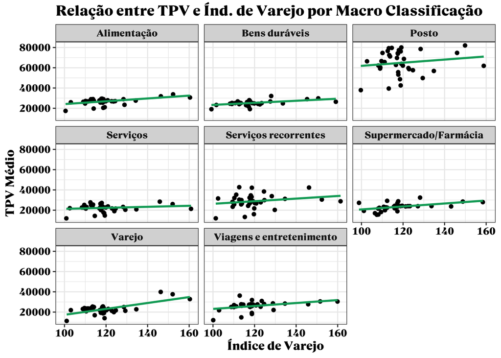

Mais uma vez vemos que nossa intuição econômica estava correta. O índice de varejo aparenta ser uma boa proxy para a performance econômica deste setor e outros, e certamete contribuirá com o poder preditivo do modelo.  
Por último vamos visualizar a relação entre o número de demissões contabilizado pelo CAGED e o TPV Mensal:

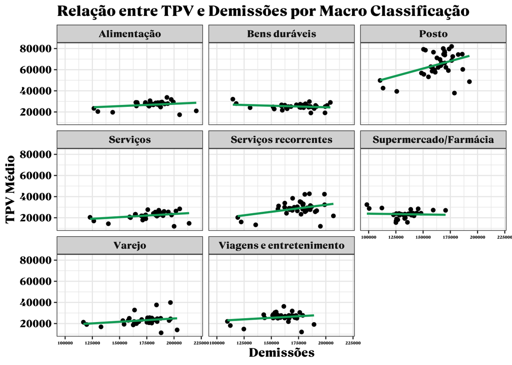

Nesse caso a relação não fica tão clara ou interpretável. Vemos que o faturamento de postos de gasolina claramente aumenta em meses com mais demissões, algo muito interessante.  
Para finalizar gostaria de dizer mais uma vez que todas as variáveis que trouxe do ipea podem ter uma importância especial para um grupo específico de clientes. Dessa forma é válido deixá-las no modelo. Não adicionei mais variáveis pois pretendo adicionar vários lags e médias móveis para todas as variáveis listadas. Dessa forma espero que o número de variáveis regressoras aumente de forma substancial na etapa de feature engineering.